# Week 5

Hao Ye

February 08, 2017

# 1 Objectives

# 2 Review of ggplot

## 2.1 Load the dataset from week 3

```r
dat <- read.csv("../week-3/EconomistData.csv") # note the path
head(dat)
```

```
##   X     Country HDI.Rank   HDI CPI            Region
## 1 1 Afghanistan      172 0.398 1.5      Asia Pacific
## 2 2     Albania       70 0.739 3.1 East EU Cemt Asia
## 3 3     Algeria       96 0.698 2.9              MENA
## 4 4      Angola      148 0.486 2.0               SSA
## 5 5   Argentina       45 0.797 3.0          Americas
## 6 6     Armenia       86 0.716 2.6 East EU Cemt Asia
```

## 2.2 Scatter plot with CPI on the x axis and HDI on the y axis

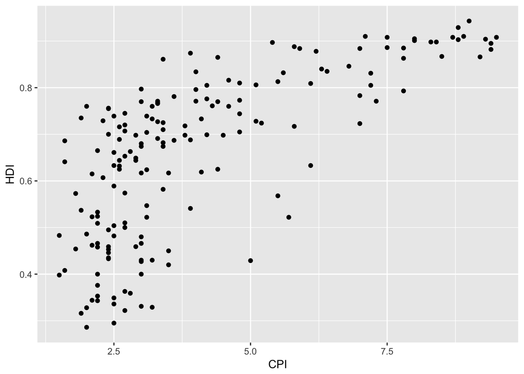

```r
library(ggplot2)
my_plot <- ggplot(dat, aes(x = CPI, y = HDI)) +
    geom_point()
print(my_plot)
```

## 2.3 Scatter plot, with colors and shapes for each region, and different theme

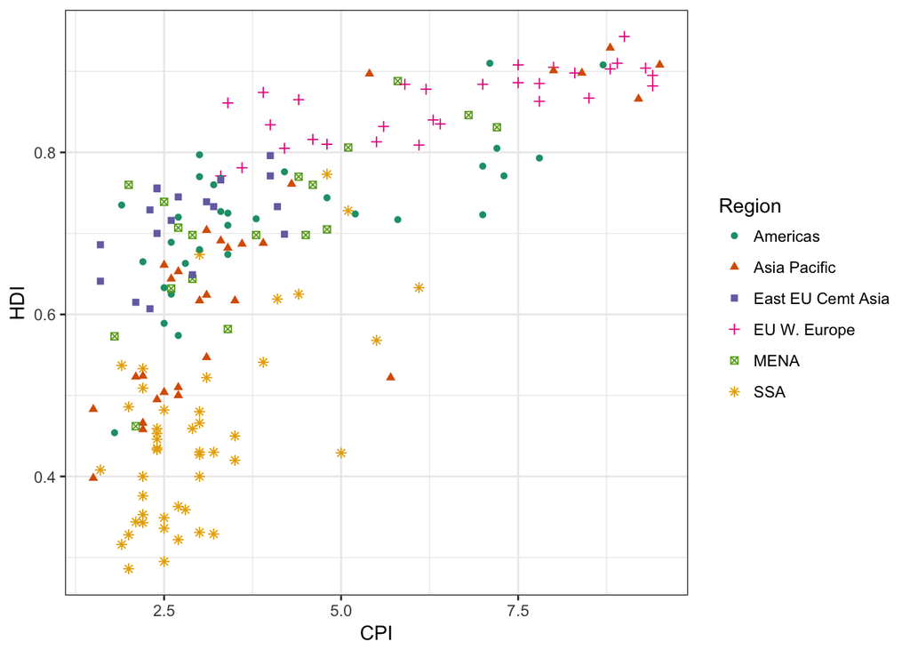

```r
my_plot <- ggplot(dat, aes(x = CPI, y = HDI,
                           color = Region, shape = Region)) +
    geom_point() +
    scale_color_brewer(palette = "Dark2") +
    theme_bw()
print(my_plot)
```

# 3 More geom types

## 3.1 1-D summary of data

### 3.1.1 Histograms

A simple histogram of `CPI` values using `geom_histogram`

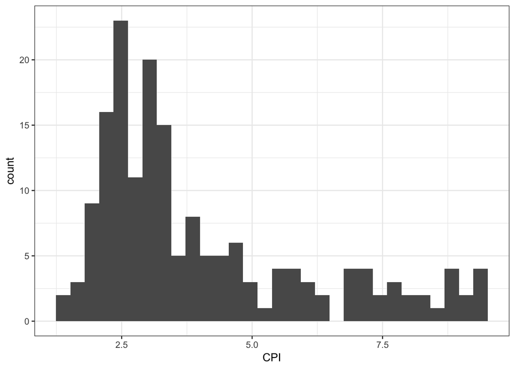

```r
my_plot <- ggplot(dat, aes(x = CPI)) +
    geom_histogram() +
    theme_bw()
print(my_plot)
```

A stacked version, with different colors by region

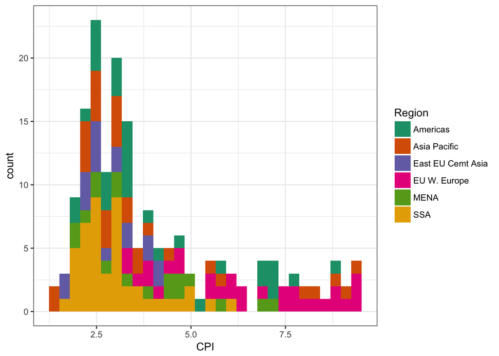

```r
my_plot <- ggplot(dat, aes(x = CPI, fill = Region)) +
    geom_histogram() +
    scale_fill_brewer(palette = "Dark2") +
    theme_bw()
print(my_plot)
```

### 3.1.2 Density Map (1D)

If we want a smoothed histogram, where the density of the underlying distribution is inferred, we can use `geom_density` instead:

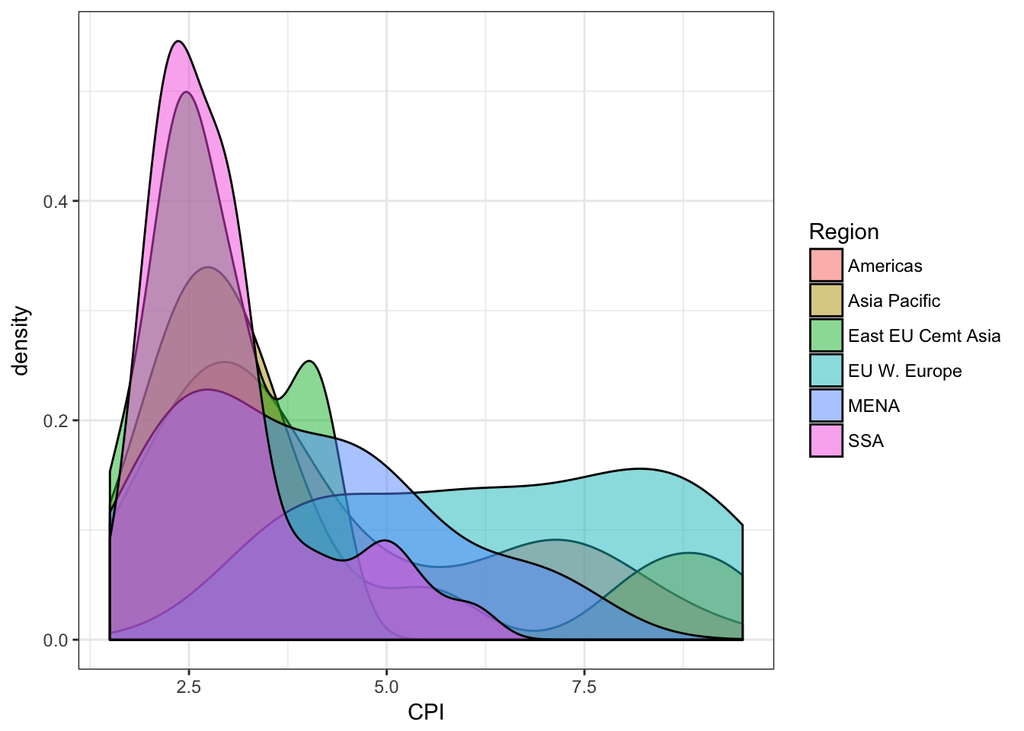

```r
my_plot <- ggplot(dat, aes(x = CPI, fill = Region)) +
    geom_density(alpha = 0.5) +
    scale_fill_hue() +
    theme_bw()
print(my_plot)
```

### 3.1.3 Violin Plots

Violin plots are similar to using `geom_density`, but in the fashion of `geom_boxplot`:

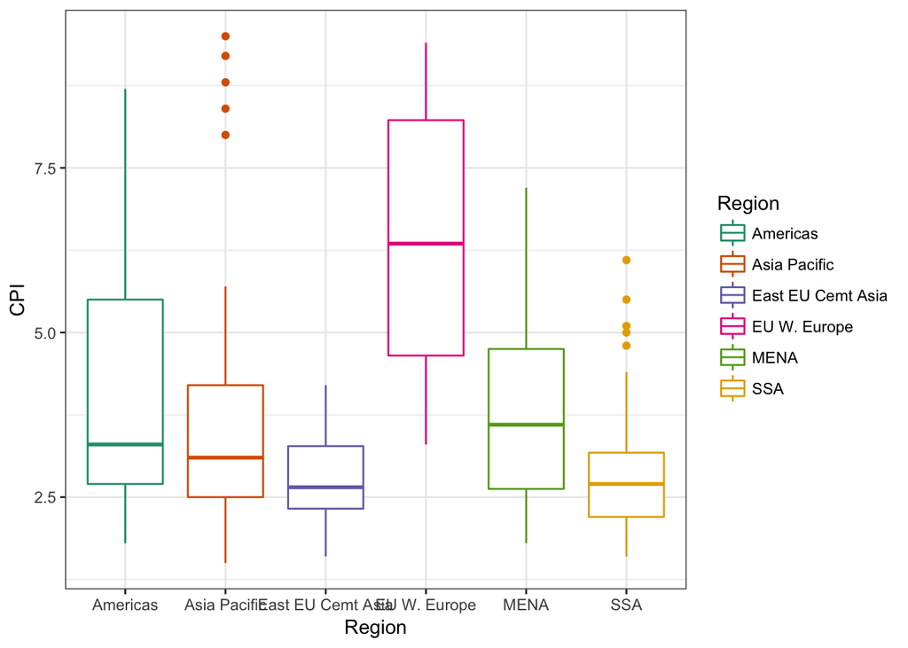

```r
my_plot <- ggplot(dat, aes(x = Region, y = CPI, color = Region)) +
    geom_boxplot() +
    scale_color_brewer(palette = "Dark2") +
    theme_bw()
print(my_plot)
```

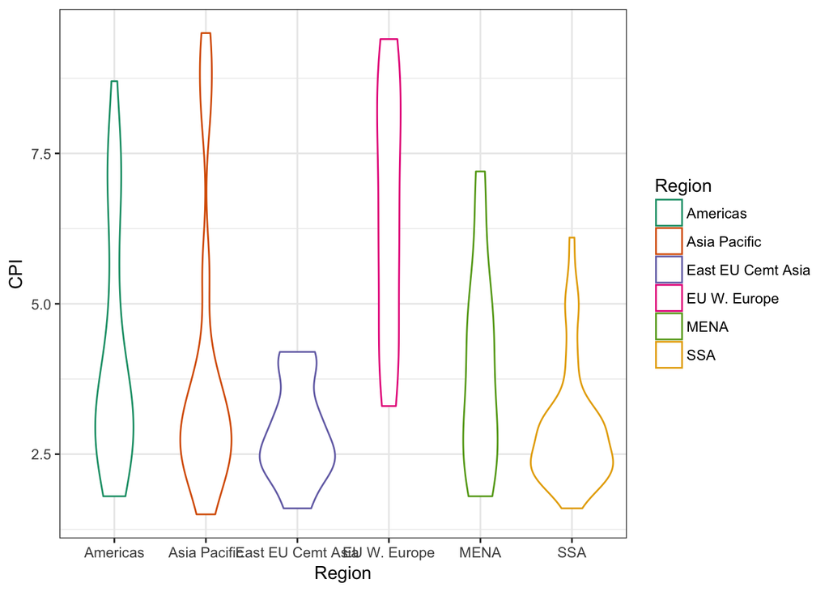

```r
my_plot <- ggplot(dat, aes(x = Region, y = CPI, color = Region)) +
    geom_violin() +
    scale_color_brewer(palette = "Dark2") +
    theme_bw()
print(my_plot)
```

## 3.2 2-D summary of data

If we have two axes we want to visualize at the same time, then we need slightly different geoms.

### 3.2.1 Histograms (2D)

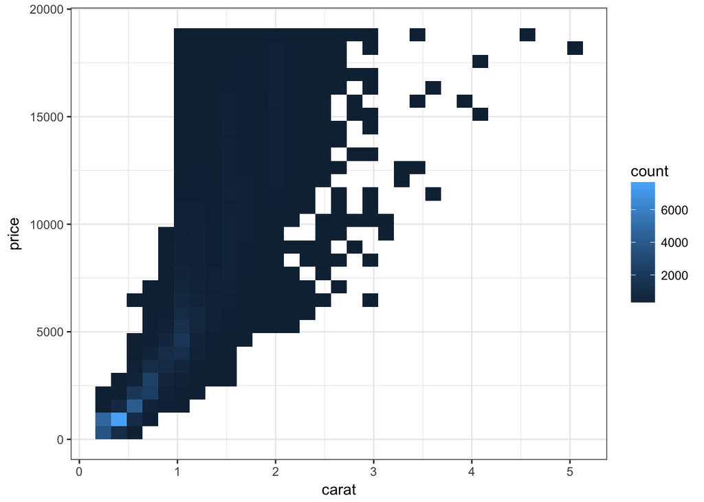

```r
my_plot <- ggplot(diamonds, aes(x = carat, y = price)) +
    geom_bin2d() +
    theme_bw()
print(my_plot)
```

### 3.2.2 Histogram (2D Hexes)

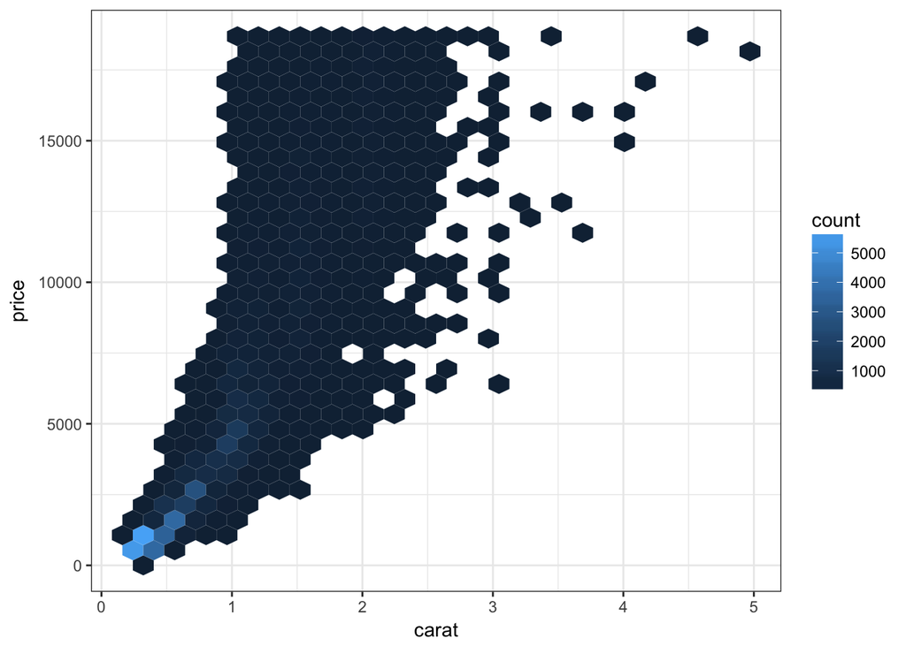

```r
my_plot <- ggplot(diamonds, aes(x = carat, y = price)) +
    geom_hex() +
    theme_bw()
print(my_plot)
```

### 3.2.3 Density Map (2D)

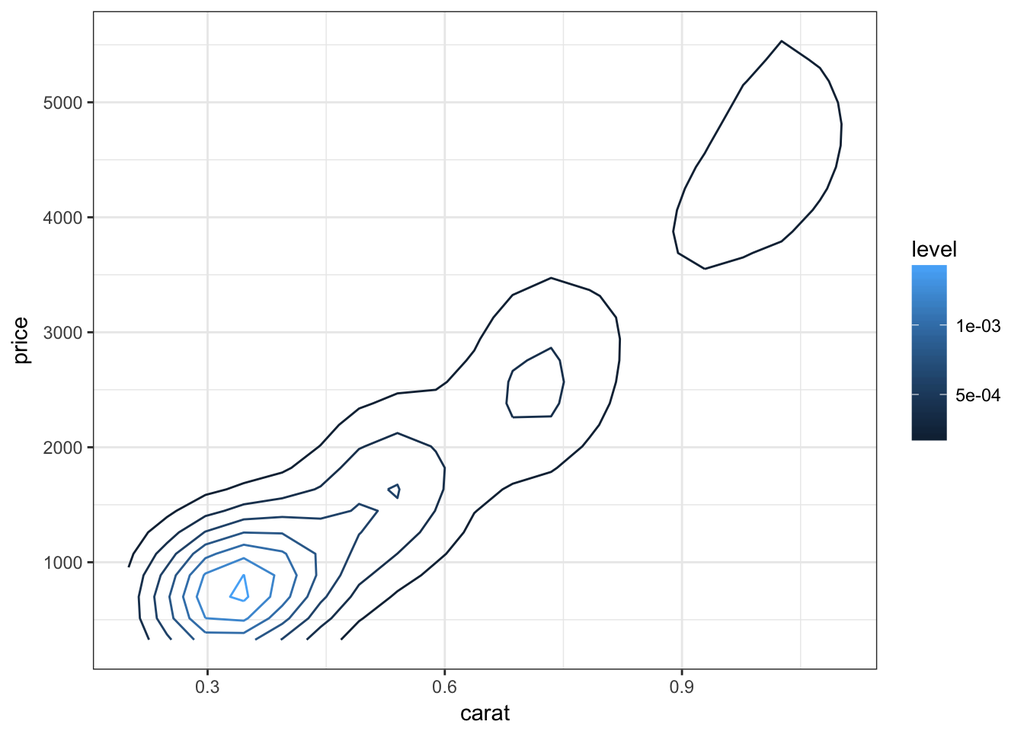

```r
my_plot <- ggplot(diamonds, aes(x = carat, y = price)) +
    geom_density2d(aes(color = ..level..)) +
    theme_bw()
print(my_plot)
```

## 3.3 Error Bars

Here, we use jitter to space out the points, and then add in the mean and standard error as summary values:

```
## No summary function supplied, defaulting to `mean_se()
```

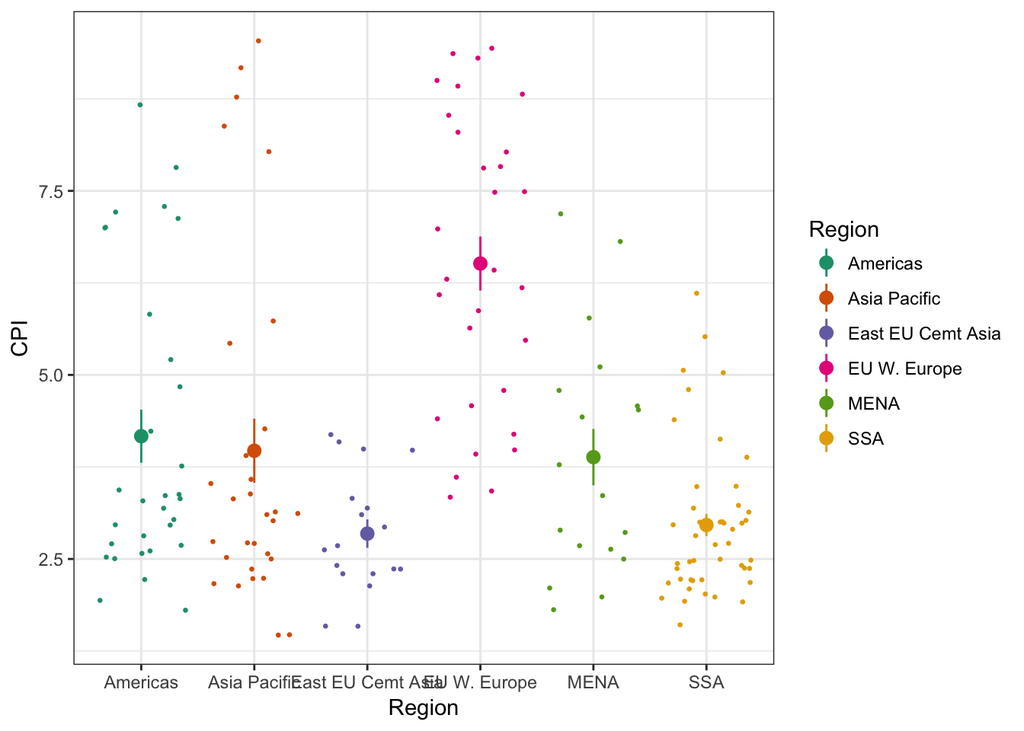

```r
my_plot <- ggplot(dat, aes(x = Region, y = CPI, color = Region)) +
    geom_point(size = 0.5, position = "jitter") +
    stat_summary() +
    scale_color_brewer(palette = "Dark2") +
    theme_bw()
print(my_plot)
```

The point and line is a bit hard to see, so let's use an alternate geom:

```
## No summary function supplied, defaulting to `mean_se()
```

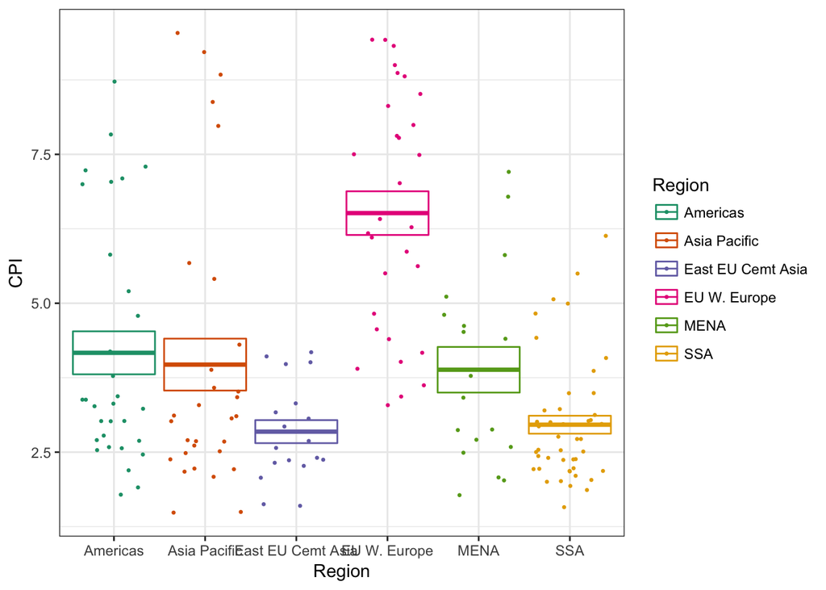

```r
my_plot <- ggplot(dat, aes(x = Region, y = CPI, color = Region)) +
    geom_point(size = 0.5, position = "jitter") +
    stat_summary(geom = "crossbar") +
    scale_color_brewer(palette = "Dark2") +
    theme_bw()
print(my_plot)
```

A more typical plot might be just to plot the means as bars, with error bars. Note that we have to specify for `geom_bar` that we don't want to plot the raw values (since there are multiple points for each region), but rather to compute the mean for each group.

```
## No summary function supplied, defaulting to `mean_se()
```

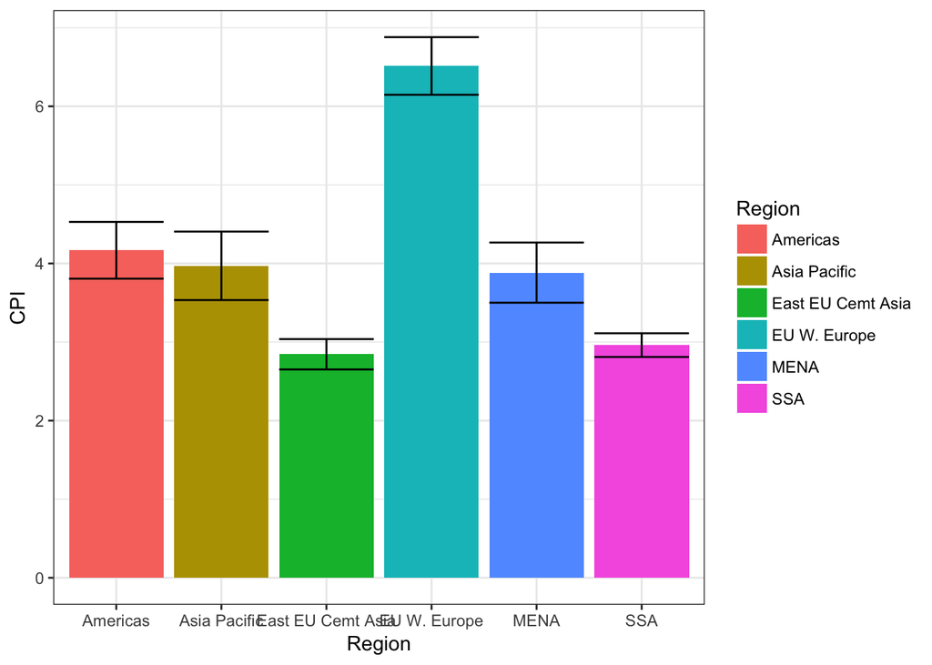

```r
my_plot <- ggplot(dat, aes(x = Region, y = CPI, fill = Region)) +
    geom_bar(stat = "summary", fun.y = "mean") +
    geom_errorbar(stat = "summary") +
    scale_color_brewer(palette = "Dark2") +
    theme_bw()
print(my_plot)
```

Note that the previous plot uses means and standard errors. If we wanted to plot confidence intervals, we need a slightly different function, in this case, from the `Hmisc` package.

```r
library(Hmisc)
```

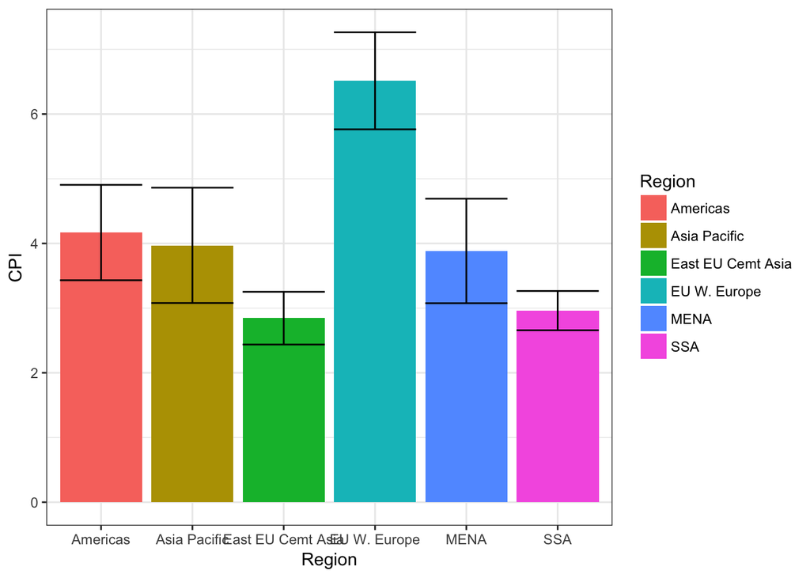

```r
my_plot <- ggplot(dat, aes(x = Region, y = CPI, fill = Region)) +
    geom_bar(stat = "summary", fun.y = "mean") +
    geom_errorbar(fun.data = mean_cl_normal, stat = "summary") +
    scale_color_brewer(palette = "Dark2") +
    theme_bw()
print(my_plot)
```

# 4 Other Plot Tweaks

## 4.1 Coordinate Transformations

If we want to zoom in (or out) on a portion of the plot, we can manually set the plot limits using `coord_cartesian`.

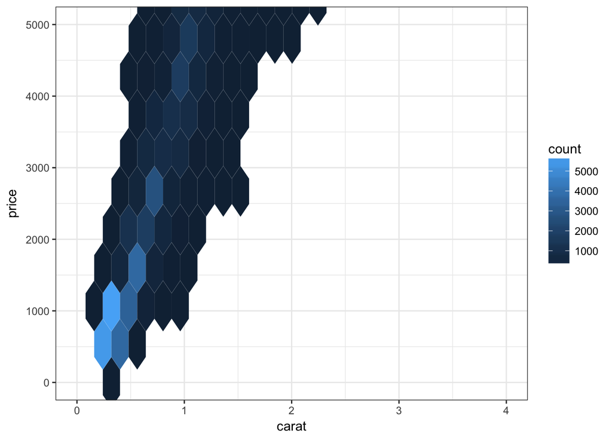

```r
my_plot <- ggplot(diamonds, aes(x = carat, y = price)) +
    geom_hex() +
    coord_cartesian(xlim = c(0, 4), ylim = c(0, 5000)) +
    theme_bw()
print(my_plot)
```

Note that this is different from using `scale_x_continuous` (and similar), which actually restricts the data before plotting (which may cut off objects)

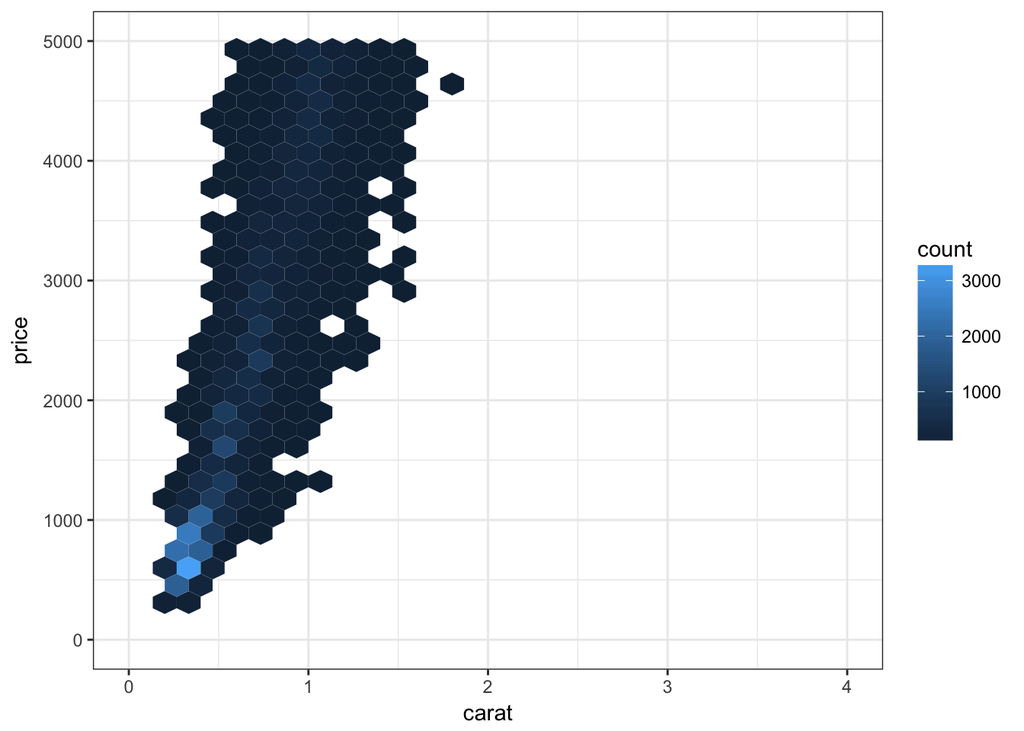

```r
my_plot <- ggplot(diamonds, aes(x = carat, y = price)) +
    geom_hex() +
    scale_x_continuous(limits = c(0, 4)) +
    scale_y_continuous(limits = c(0, 5000)) +
    theme_bw()
print(my_plot)
```

Similarly, we can set a log axis:

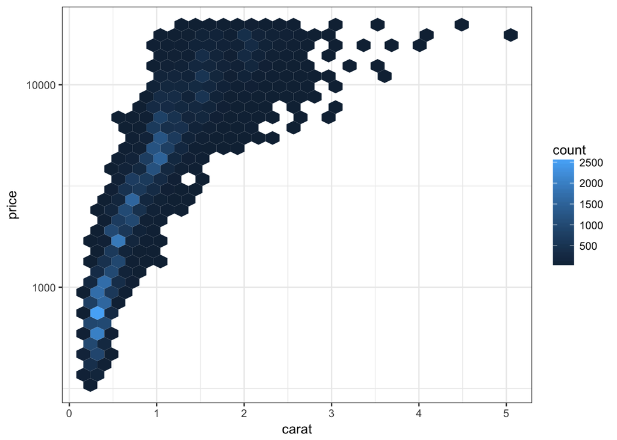

```r
my_plot <- ggplot(diamonds, aes(x = carat, y = price)) +
    geom_hex() +
    scale_y_log10() +
    theme_bw()
print(my_plot)
```

# 5 Multiple panels using facets

If we want to visualize separate plots for different categorical variables, we can use the facet system in ggplot:

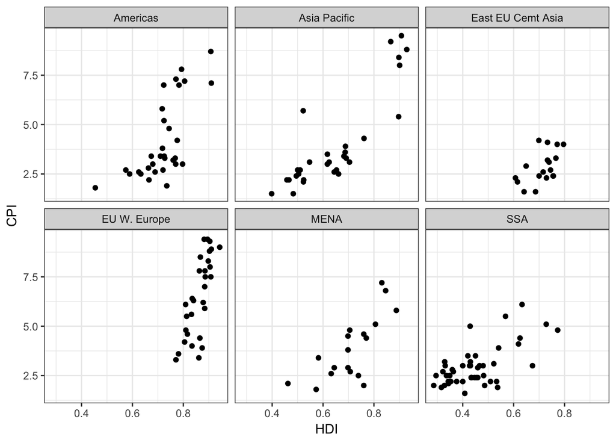

```r
my_plot <- ggplot(dat, aes(x = HDI, y = CPI)) +
    geom_point() +
    facet_wrap(~ Region) +
    theme_bw()
print(my_plot)
```

Note that by default, it uses the same axes, which facilitates visual comparison. But this can be turned off:

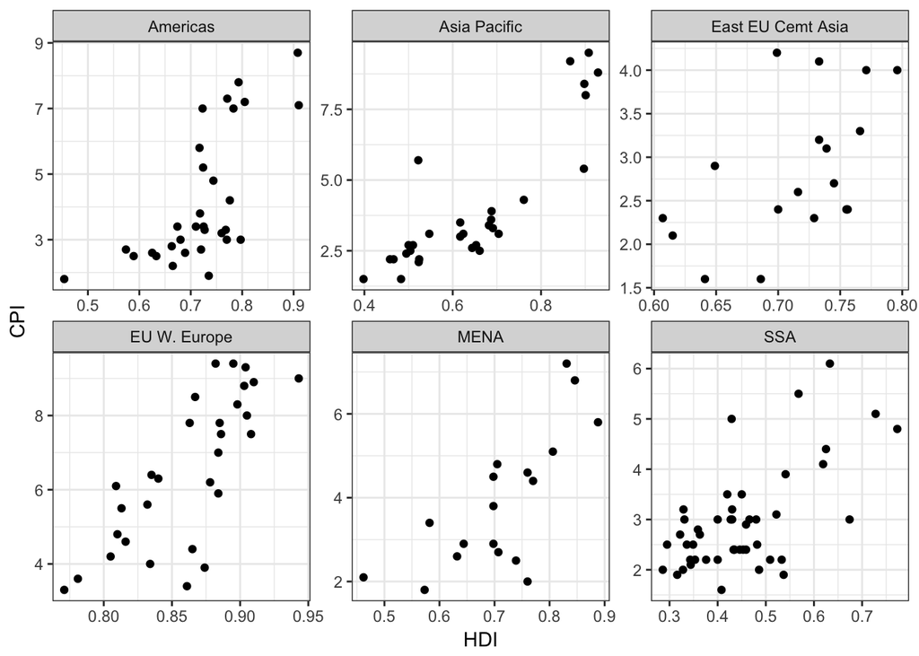

```r
my_plot <- ggplot(dat, aes(x = HDI, y = CPI)) +
    geom_point() +
    facet_wrap(~ Region, scales = "free") +
    theme_bw()
print(my_plot)
```

# 6 Multiple panels using different ggplot objects

Facets work when the plots are all the same type, but what if we want a generic multiple panel figure?

```r
library(gridExtra)
```

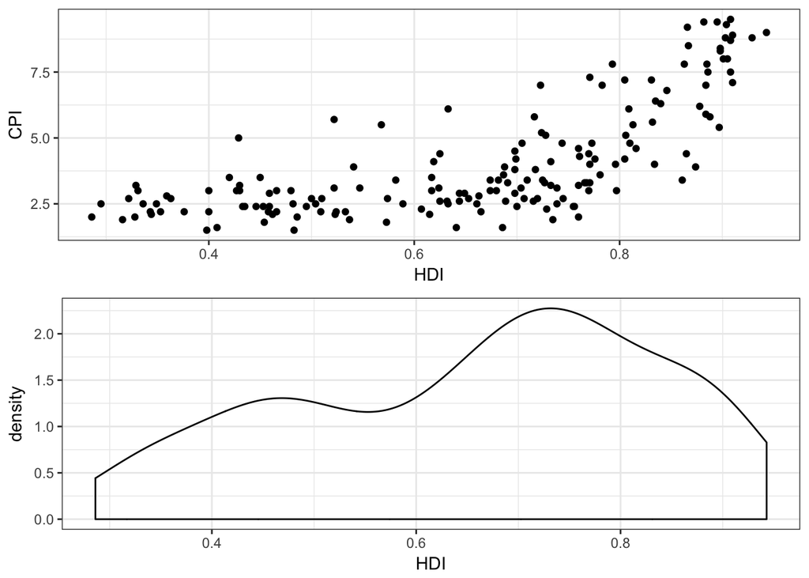

```r
plot_1 <- ggplot(dat, aes(x = HDI, y = CPI)) +
    geom_point() +
    theme_bw()

plot_2 <- ggplot(dat, aes(x = HDI)) +
    geom_density() +
    theme_bw()

grid.arrange(plot_1, plot_2)
```

# 7 Exercises

Try to make some of these other kinds of plots:

1. Stacked bar plots
2. Stacked area plots (see `geom_area` and `geom_ribbon`)
3. Other???

# 8 Resources

- [ggplot gallery -- http://www.r-graph-gallery.com/portfolio/ggplot2-package/](http://www.r-graph-gallery.com/portfolio/ggplot2-package/)
- [extensions to ggplot (other packages) -- http://www.ggplot2-exts.org/gallery/](http://www.ggplot2-exts.org/gallery/)
- [various tweaks to prettify a ggplot figure -- http://zevross.com/blog/2014/08/04/beautiful-plotting-in-r-a-ggplot2-cheatsheet-3/](http://zevross.com/blog/2014/08/04/beautiful-plotting-in-r-a-ggplot2-cheatsheet-3/)